# Final Project

##Does an apple a day keep the doctor away?

What will an apple/day mean? Fruit consumed kgs/capita/year, cal from plant protein, calories from animal protein, calories from fat

What does keep the doctor away mean? It can mean dalys, cancer prevalence, depressive disorders, life expectancy.

My first question is: is our data normalized? Here I take steps to normalize the data from the columns where the skewness coefficient is not within the range (-0.6:0.6). I normalize the data by applying the sqrt() function and overwriting those same columns with excessive skew.

```r
var <- select(df, -c(entity, total_pop, year, continent))
col <- data.frame(names(var))

var_skew <- data.frame(col, apply(var, 2, skewness, na.rm = TRUE))
print(var_skew)
```

```
##                                                                      names.var.
## kg_apple_prod_capita_year                             kg_apple_prod_capita_year
## cal_frm_animl_prot                                           cal_frm_animl_prot
## cal_frm_plnt_prot                                             cal_frm_plnt_prot
## cal_frm_fat                                                         cal_frm_fat
## cal_frm_carbs                                                     cal_frm_carbs
## fruit_consumed_kg_pc_year                             fruit_consumed_kg_pc_year
## gdp_capita_year                                                 gdp_capita_year
## life_expectancy                                                 life_expectancy
## deaths_neoplasms                                               deaths_neoplasms
## daly                                                                       daly
## percent_prevalence_depressive_disorders percent_prevalence_depressive_disorders
##                                         apply.var..2..skewness..na.rm...TRUE.
## kg_apple_prod_capita_year                                           2.1651510
## cal_frm_animl_prot                                                  0.3596804
## cal_frm_plnt_prot                                                   0.9739459
## cal_frm_fat                                                         0.1820004
## cal_frm_carbs                                                       0.5321906
## fruit_consumed_kg_pc_year                                           1.6808241
## gdp_capita_year                                                     1.2755421
## life_expectancy                                                    -0.8265551
## deaths_neoplasms                                                    7.7923871
## daly                                                                2.0615464
## percent_prevalence_depressive_disorders                             1.0583714
```

```r
skewed_bad <- filter(var_skew, !between(var_skew$apply.var..2..skewness..na.rm...TRUE., -0.6, 0.6))

skewed_bad$names.var.
```

```
## [1] "kg_apple_prod_capita_year"
## [2] "cal_frm_plnt_prot"
## [3] "fruit_consumed_kg_pc_year"
## [4] "gdp_capita_year"
## [5] "life_expectancy"
## [6] "deaths_neoplasms"
## [7] "daly"
## [8] "percent_prevalence_depressive_disorders"
```

```r
df2 <- df
df2[,skewed_bad$names.var.] <- df2 %>%
  select(skewed_bad$names.var.) %>%
  apply(2, sqrt)
```

Now that my data is normalized, lets compare the best known predictor of life expectancy (GDP) to apple production.

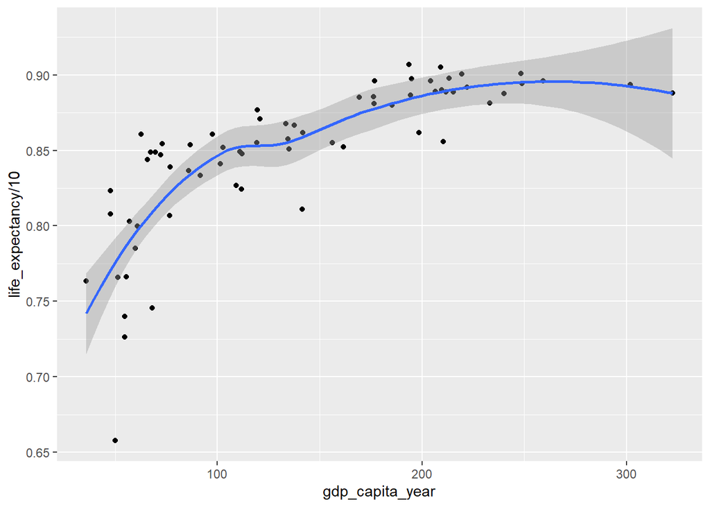

```r
df2 %>%
  filter(year == 2005) %>%
  ggplot(aes(x = gdp_capita_year, y = life_expectancy/10))+
  geom_point()+
  geom_smooth()
```

```r
mod <- glm(life_expectancy ~ gdp_capita_year, data = df2)
summary(mod)
```

```
##
## Call:
## glm(formula = life_expectancy ~ gdp_capita_year, data = df2)
##
## Deviance Residuals:
##      Min        1Q    Median        3Q       Max
## -1.48381  -0.13500   0.06972   0.17763   0.52766
##
## Coefficients:
##                  Estimate Std. Error t value Pr(>|t|)
## (Intercept)     7.771e+00  1.493e-02   520.6   <2e-16 ***
## gdp_capita_year 5.272e-03  9.692e-05    54.4   <2e-16 ***
## ---
## Signif. codes:  0 '***' 0.001 '**' 0.01 '*' 0.05 '.' 0.1 ' ' 1
##
## (Dispersion parameter for gaussian family taken to be 0.08876483)
##
##     Null deviance: 437.99  on 1976  degrees of freedom
## Residual deviance: 175.31  on 1975  degrees of freedom
##   (13696 observations deleted due to missingness)
## AIC: 826.65
##
## Number of Fisher Scoring iterations: 2
```

Let’s compare that to kilograms of apples produced and my other dependent variables:

```r
names(df2)
```

```
##  [1] "entity"
##  [2] "year"
##  [3] "total_pop"
##  [4] "continent"
##  [5] "kg_apple_prod_capita_year"
##  [6] "cal_frm_animl_prot"
##  [7] "cal_frm_plnt_prot"
##  [8] "cal_frm_fat"
##  [9] "cal_frm_carbs"
## [10] "fruit_consumed_kg_pc_year"
## [11] "gdp_capita_year"
## [12] "life_expectancy"
## [13] "deaths_neoplasms"
## [14] "daly"
## [15] "percent_prevalence_depressive_disorders"
```

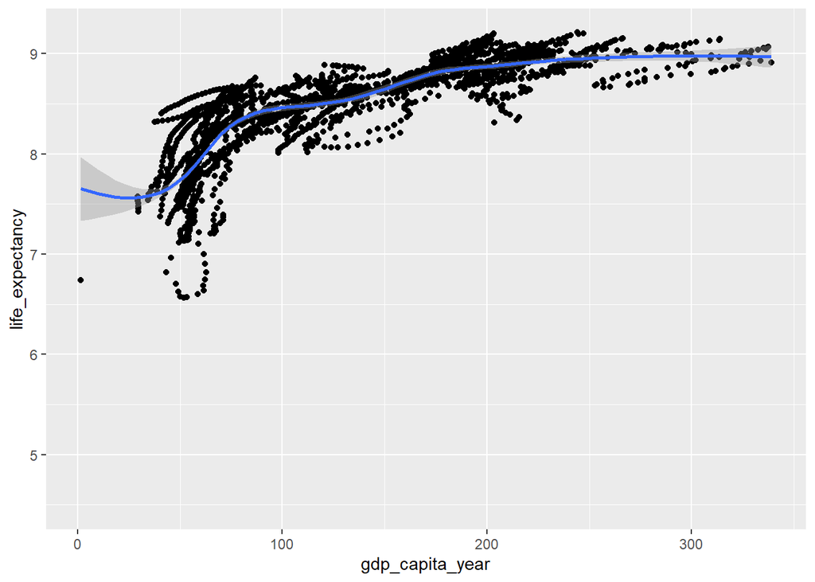

```r
df2 %>%
  ggplot(aes(x = gdp_capita_year, y = life_expectancy))+
  geom_point()+
  geom_smooth()
```

```r
mod1 <-  glm(life_expectancy ~ gdp_capita_year,
             data = df2)

gdp_life <- tidy(mod1)

print(gdp_life)
```

```
## # A tibble: 2 x 5
##   term            estimate std.error statistic p.value
##   <chr>              <dbl>     <dbl>     <dbl>   <dbl>
## 1 (Intercept)      7.77    0.0149        521.        0
## 2 gdp_capita_year  0.00527 0.0000969      54.4       0
```

GDP for sure has an effect, albeit a tiny effect, estimated at 0.005 for a change in GDP

Let’s measure the effect of each of my independent variables against life expectancy and compile them into one table

```r
names(df2)
```

```
##  [1] "entity"
##  [2] "year"
##  [3] "total_pop"
##  [4] "continent"
##  [5] "kg_apple_prod_capita_year"
##  [6] "cal_frm_animl_prot"
##  [7] "cal_frm_plnt_prot"
##  [8] "cal_frm_fat"
##  [9] "cal_frm_carbs"
## [10] "fruit_consumed_kg_pc_year"
## [11] "gdp_capita_year"
## [12] "life_expectancy"
## [13] "deaths_neoplasms"
## [14] "daly"
## [15] "percent_prevalence_depressive_disorders"
```

```r
#apples are mod2
mod2 <-  glm(life_expectancy ~ kg_apple_prod_capita_year,
             data = df2)
apl_life <- tidy(mod2)
#cal from animal protein is mod3
mod3 <-  glm(life_expectancy ~ cal_frm_animl_prot,
             data = df2)
animl_life <- tidy(mod3)
#cal from plant protein is mod4
mod4 <-  glm(life_expectancy ~ cal_frm_plnt_prot,
             data = df2)
plnt_life <- tidy(mod4)
#cal from fat is mod5
mod5 <-  glm(life_expectancy ~ cal_frm_fat,
             data = df2)
fat_life <- tidy(mod5)
#cal from carbs is mod6
mod6 <-  glm(life_expectancy ~ cal_frm_carbs,
             data = df2)
carbs_life <- tidy(mod6)
#fruit consumer per capit is mod7
mod7 <-  glm(life_expectancy ~ fruit_consumed_kg_pc_year,
             data = df2)
fruit_life <- tidy(mod7)

#full join
a <- full_join(apl_life, fat_life)
b <- full_join(a,plnt_life)
c <- full_join(b,animl_life)
d <- full_join(c, gdp_life)
e <- full_join(d, carbs_life)
sum <- full_join(e, fruit_life)


sum <- sum %>%
  filter(term != "(Intercept)") %>%
  select(term, estimate, p.value)

print(sum)
```

```
## # A tibble: 7 x 3
##   term                       estimate   p.value
##   <chr>                         <dbl>     <dbl>
## 1 kg_apple_prod_capita_year  0.219    0
## 2 cal_frm_fat                0.00132  0
## 3 cal_frm_plnt_prot         -0.0138   4.51e-  2
## 4 cal_frm_animl_prot         0.00524  0
## 5 gdp_capita_year            0.00527  0
## 6 cal_frm_carbs              0.000473 6.51e- 30
## 7 fruit_consumed_kg_pc_year  0.0372   1.78e-130
```

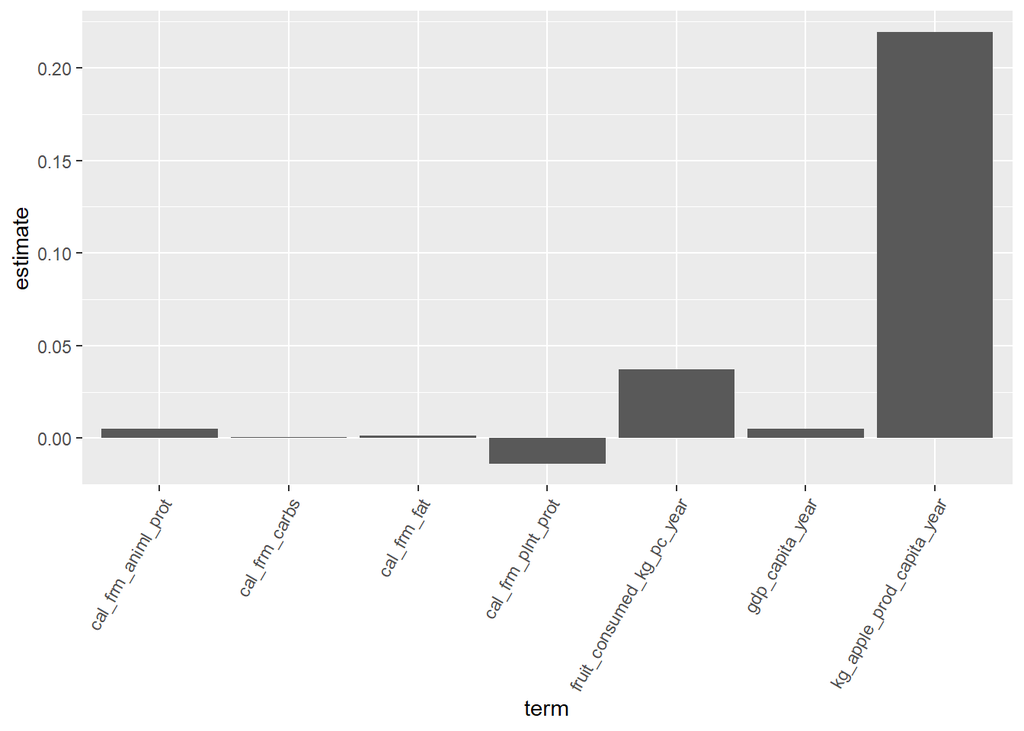

```r
sum %>%
  ggplot(aes(x = term, y = estimate)) +
  geom_col()+
  theme(axis.text.x = element_text(angle = 60,
        vjust = 1, hjust = 1))
```

WOW… I was not expecting that. Kilograms of apples produced per capita has a much larger effect than ANY of my other independant variables. Let’s visualize this data:

```r
names(df2)
```

```
##  [1] "entity"
##  [2] "year"
##  [3] "total_pop"
##  [4] "continent"
##  [5] "kg_apple_prod_capita_year"
##  [6] "cal_frm_animl_prot"
##  [7] "cal_frm_plnt_prot"
##  [8] "cal_frm_fat"
##  [9] "cal_frm_carbs"
## [10] "fruit_consumed_kg_pc_year"
## [11] "gdp_capita_year"
## [12] "life_expectancy"
## [13] "deaths_neoplasms"
## [14] "daly"
## [15] "percent_prevalence_depressive_disorders"
```

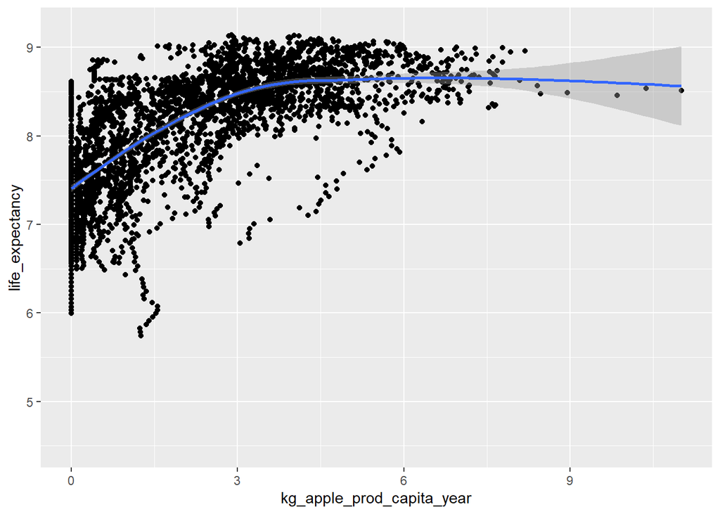

```r
df2 %>%
  ggplot(aes(x = kg_apple_prod_capita_year, y = life_expectancy))+
  geom_point()+
  geom_smooth()
```

```r
df %>%
  filter(year == 2019) %>%
  select(year, life_expectancy) %>%
  summary(life_expectancy)
```

```
##       year      life_expectancy
##  Min.   :2019   Min.   :57.40
##  1st Qu.:2019   1st Qu.:72.59
##  Median :2019   Median :76.91
##  Mean   :2019   Mean   :76.17
##  3rd Qu.:2019   3rd Qu.:81.54
##  Max.   :2019   Max.   :84.86
```

According to our data, the average life expectancy in 2019 was approximately 76 years. How well will production of apples (our strongest correlation to life expectancy) predict whether a person will live at least to 76?

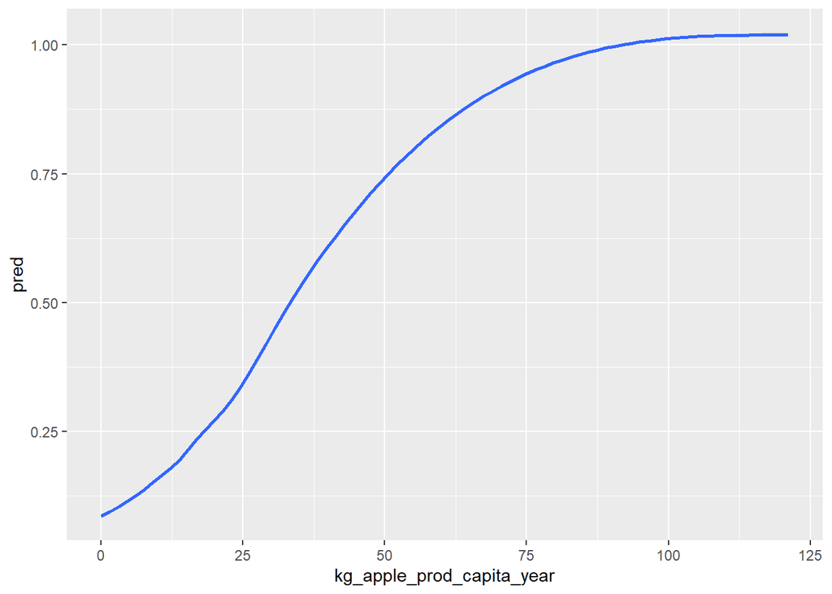

```r
df <- df %>%
mutate("makes_avg" = case_when(life_expectancy >= 76 ~ TRUE,
                        TRUE~FALSE))
mod8<- glm(data = df,
              formula = makes_avg ~ kg_apple_prod_capita_year,
              family = "binomial")

df %>%
     add_predictions(mod8, type = "response") %>%
     ggplot(aes(x = kg_apple_prod_capita_year, y = pred)) +
     geom_smooth()
```

That is a perfect logistical curve if I’ve ever seen one! The more apples your country produces, the greater your chances of meeting an average life expectancy.

Overall, production of apples has a relatively large impact on life expectancy. I want to know if this is true for poor, medium, and affluent countries. Here I will divide GDP into 1/3s. The lower third I will classify as poor, the second third will be medium, and the upper third will be affluent. To start, I want to see if there are any differences in apple production between poor, medium, and affluent countries.

```r
names(df)
```

```
##  [1] "entity"
##  [2] "year"
##  [3] "total_pop"
##  [4] "continent"
##  [5] "kg_apple_prod_capita_year"
##  [6] "cal_frm_animl_prot"
##  [7] "cal_frm_plnt_prot"
##  [8] "cal_frm_fat"
##  [9] "cal_frm_carbs"
## [10] "fruit_consumed_kg_pc_year"
## [11] "gdp_capita_year"
## [12] "life_expectancy"
## [13] "deaths_neoplasms"
## [14] "daly"
## [15] "percent_prevalence_depressive_disorders"
## [16] "makes_avg"
```

```r
(max(df$gdp_capita_year, na.rm = TRUE)) * 0.333 #poor < 38258.1
```

```
## [1] 38258.1
```

```r
(max(df$gdp_capita_year, na.rm = TRUE)) * 0.666 #medium 38258.1-
```

```
## [1] 76516.19
```

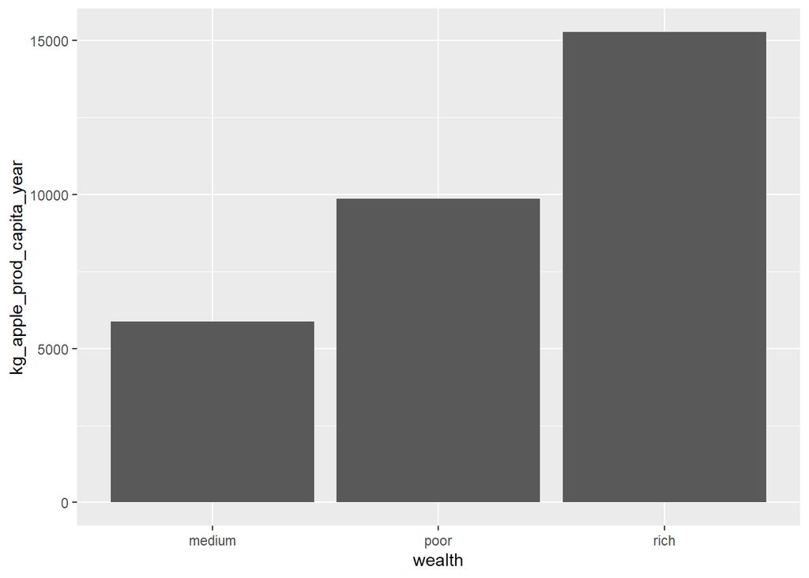

```r
df <- df %>%
  mutate("wealth" = case_when(gdp_capita_year < 38258.1 ~ "poor",
                            gdp_capita_year < 76516.18~ "medium",
                            TRUE ~ "rich"))
df %>%
  ggplot(aes(x = wealth, y = kg_apple_prod_capita_year))+
  geom_col()
```

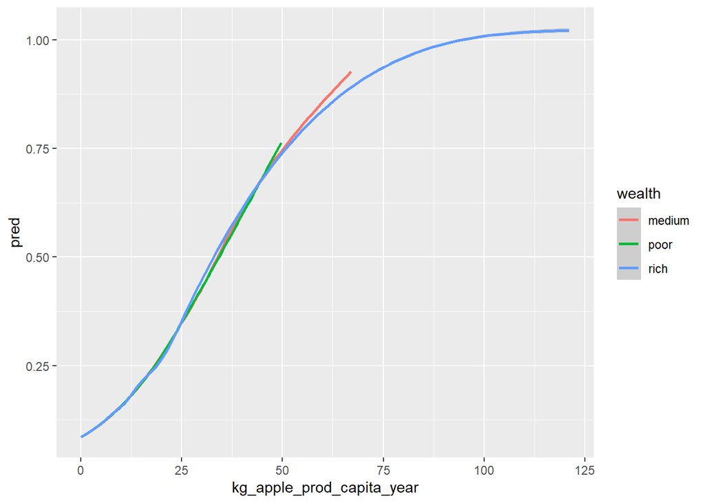

```r
df %>%
     add_predictions(mod8, type = "response") %>%
     ggplot(aes(x = kg_apple_prod_capita_year, y = pred, color = wealth)) +
     geom_smooth()
```

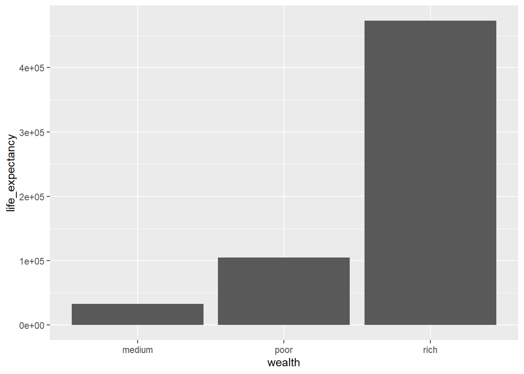

```r
df %>%
  ggplot(aes(x = wealth, y = life_expectancy))+
  geom_col()
```

```r
unique(df$wealth)
```

```
## [1] "poor"   "rich"   "medium"
```